# Mod5LabCredit

Author

Maggie Hill

Published

March 26, 2026

## Project Setup

Hopefully you have already created a folder for an R project for this assignment.

Save this `.qmd` file within your new project folder.

## Tasks for this Assignment

The `Credit` data set contains information about 1000 credit card customers. Using this data, you will develop a model to predict whether a person will default on a loan given the values of various predictor variables.

### Task 1: Load the data

Load the `Credit` data to a dataframe. Check data types to make sure they seem appropriate. Make any needed changes.

```r
creditdf <- read.csv(here(data_folder, data_file), stringsAsFactors = T)

creditdf$Default <- as.factor(creditdf$Default)
```

### Task 2: Perform EDA to familiarize yourself with the data

Put your EDA skills of summarization and visualization to work to familiarize yourself with the data. You should be able to answer the following questions:

- What is the distribution (shape, spread, typical value) of each variable? Write a sentence describing each one.

- Do any values appear to be outliers or anomalies?

Yes, the amount value appears to have an outlier with its max value being 18,424 despite its mean value being 3,271. The duration variable also has an outlier with its max value being 72 despite its mean value being 20.9.

- Do any variables appear to be related to each other?

Yes, it appears that the amount variable and the duration variable are related to each other as they both have similar distributions and outliers.

- Do any predictors appear to be related to the outcome variable?

Yes, it appears that the amount variable, duration variable, and age variable are related to the outcome variable of default. The installment variable does not appear to be related to the outcome variable of default.

```r
#find distribution of the amount variable with skewness
summary(creditdf$amount)
```

```
   Min. 1st Qu.  Median    Mean 3rd Qu.    Max.
    250    1366    2320    3271    3972   18424
```

```r
summary(creditdf$duration)
```

```
   Min. 1st Qu.  Median    Mean 3rd Qu.    Max.
    4.0    12.0    18.0    20.9    24.0    72.0
```

```r
summary(creditdf$installment)
```

```
   Min. 1st Qu.  Median    Mean 3rd Qu.    Max.
  1.000   2.000   3.000   2.973   4.000   4.000
```

```r
summary(creditdf$age)
```

```
   Min. 1st Qu.  Median    Mean 3rd Qu.    Max.
  19.00   27.00   33.00   35.55   42.00   75.00
```

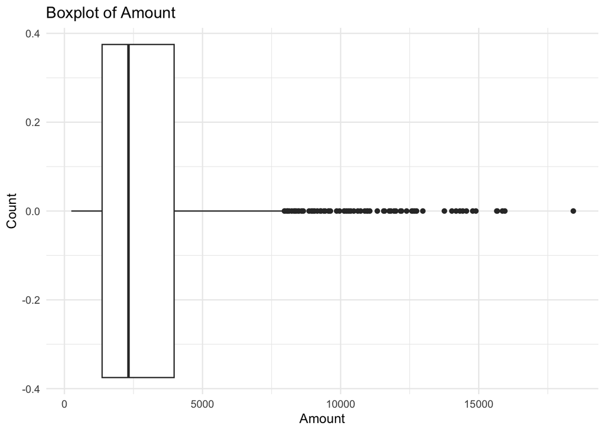

```r
#find if any values have outliers
ggplot(creditdf, aes(x=amount)) +
  geom_boxplot() +
  labs(title="Boxplot of Amount", x="Amount", y="Count") +
  theme_minimal()
```

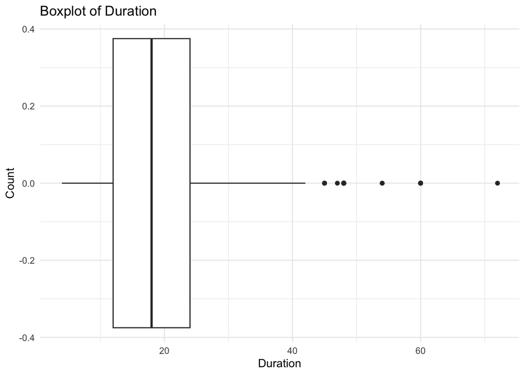

```r
ggplot(creditdf, aes(x=duration)) +
  geom_boxplot() +
  labs(title="Boxplot of Duration", x="Duration", y="Count") +
  theme_minimal()
```

```r
#group sumtable output by levels of Default
sumtable(data = creditdf, group = 'Default', add.median = T)
```

Summary Statistics

| Default Variable | 0 N | 0 Mean | 0 SD | 0 Median | 1 N | 1 Mean | 1 SD | 1 Median |
| --- | --- | --- | --- | --- | --- | --- | --- | --- |
| duration | 700 | 19 | 11 | 18 | 300 | 25 | 13 | 24 |
| amount | 700 | 2985 | 2401 | 2244 | 300 | 3938 | 3536 | 2574 |
| installment | 700 | 2.9 | 1.1 | 3 | 300 | 3.1 | 1.1 | 4 |
| age | 700 | 36 | 11 | 34 | 300 | 34 | 11 | 31 |
| history | 700 |  |  |  | 300 |  |  |  |
| ... good | 36 | 5% |  |  | 53 | 18% |  |  |
| ... poor | 421 | 60% |  |  | 197 | 66% |  |  |
| ... terrible | 243 | 35% |  |  | 50 | 17% |  |  |
| purpose | 700 |  |  |  | 300 |  |  |  |
| ... biz | 70 | 10% |  |  | 39 | 13% |  |  |
| ... edu | 36 | 5% |  |  | 23 | 8% |  |  |
| ... goods/repair | 363 | 52% |  |  | 132 | 44% |  |  |
| ... newcar | 145 | 21% |  |  | 89 | 30% |  |  |
| ... usedcar | 86 | 12% |  |  | 17 | 6% |  |  |
| foreign | 700 |  |  |  | 300 |  |  |  |
| ... foreign | 667 | 95% |  |  | 296 | 99% |  |  |
| ... german | 33 | 5% |  |  | 4 | 1% |  |  |
| rent | 700 |  |  |  | 300 |  |  |  |
| ... No | 591 | 84% |  |  | 230 | 77% |  |  |
| ... Yes | 109 | 16% |  |  | 70 | 23% |  |  |

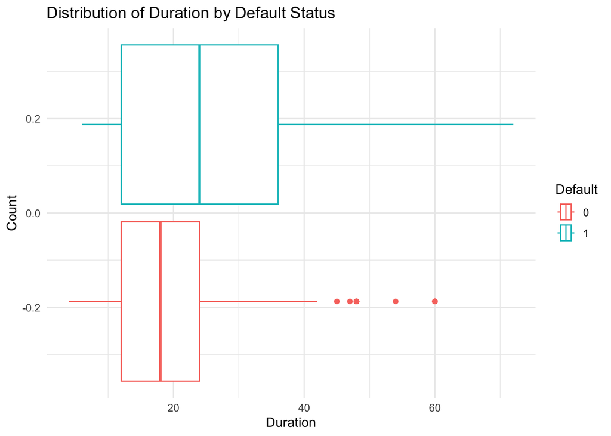

```r
#example boxplots by level of default
ggplot(creditdf, aes(x=duration, color=Default)) +
  geom_boxplot() +
  labs(title="Distribution of Duration by Default Status", x="Duration", y="Count") +
  theme_minimal()
```

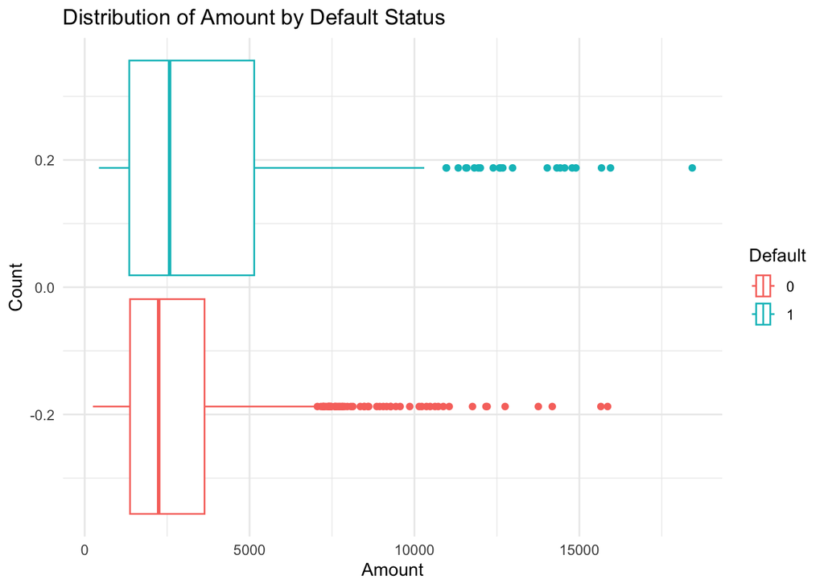

```r
ggplot(creditdf, aes(x=amount, color=Default)) +
  geom_boxplot() +
  labs(title="Distribution of Amount by Default Status", x="Amount", y="Count") +
  theme_minimal()
```

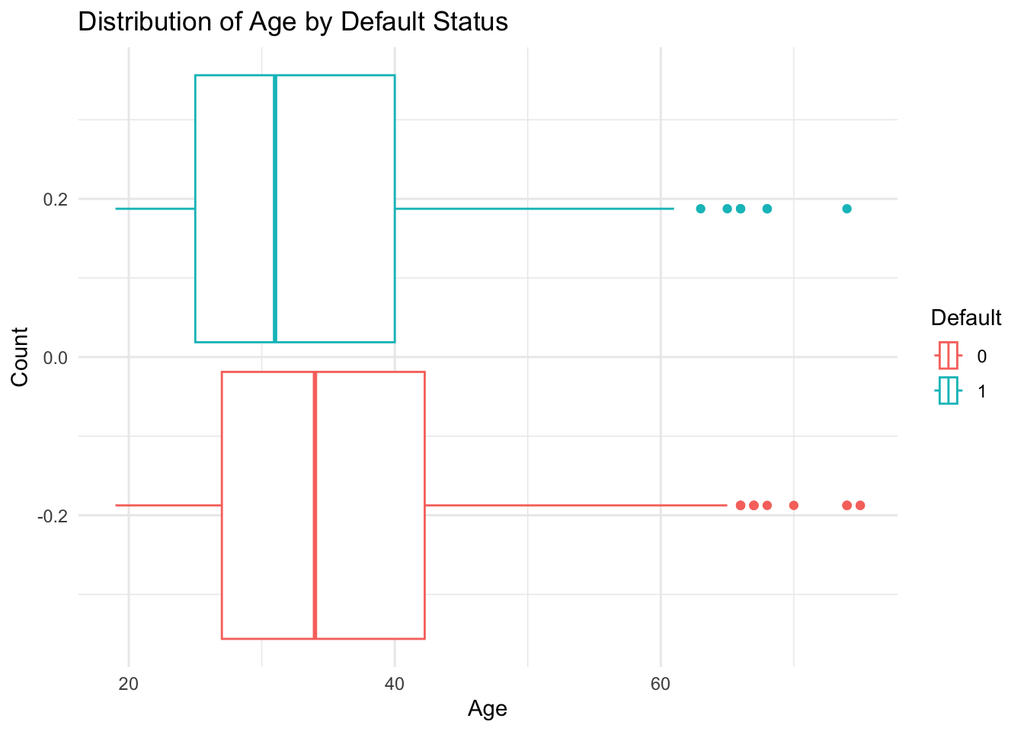

```r
ggplot(creditdf, aes(x=age, color=Default)) +
  geom_boxplot() +
  labs(title="Distribution of Age by Default Status", x="Age", y="Count") +
  theme_minimal()
```

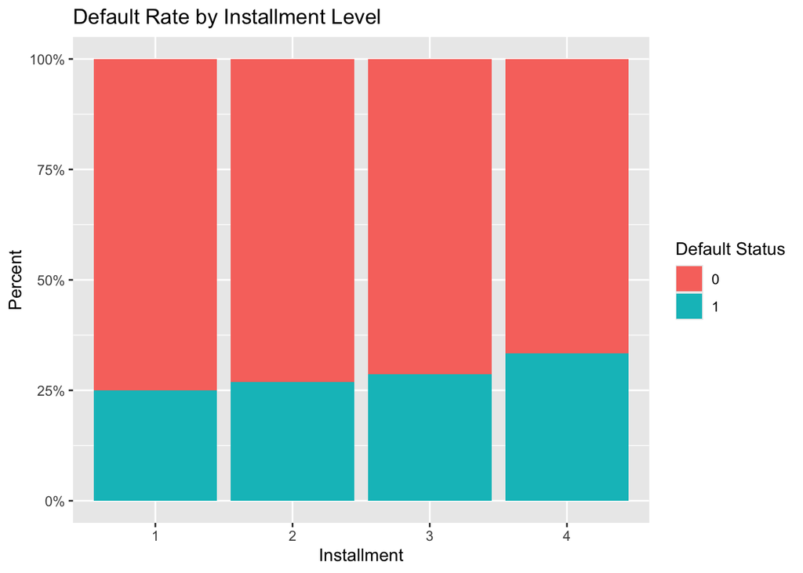

```r
# example compare default rates across levels of 2nd categorical variable (stacked proportions)
ggplot(creditdf) +
  geom_bar(aes(x = factor(installment), fill = factor(Default)), position = "fill") +
  scale_y_continuous(labels = scales::percent) +
  labs(title = "Default Rate by Installment Level",
       x = "Installment", y = "Percent", fill = "Default Status")
```

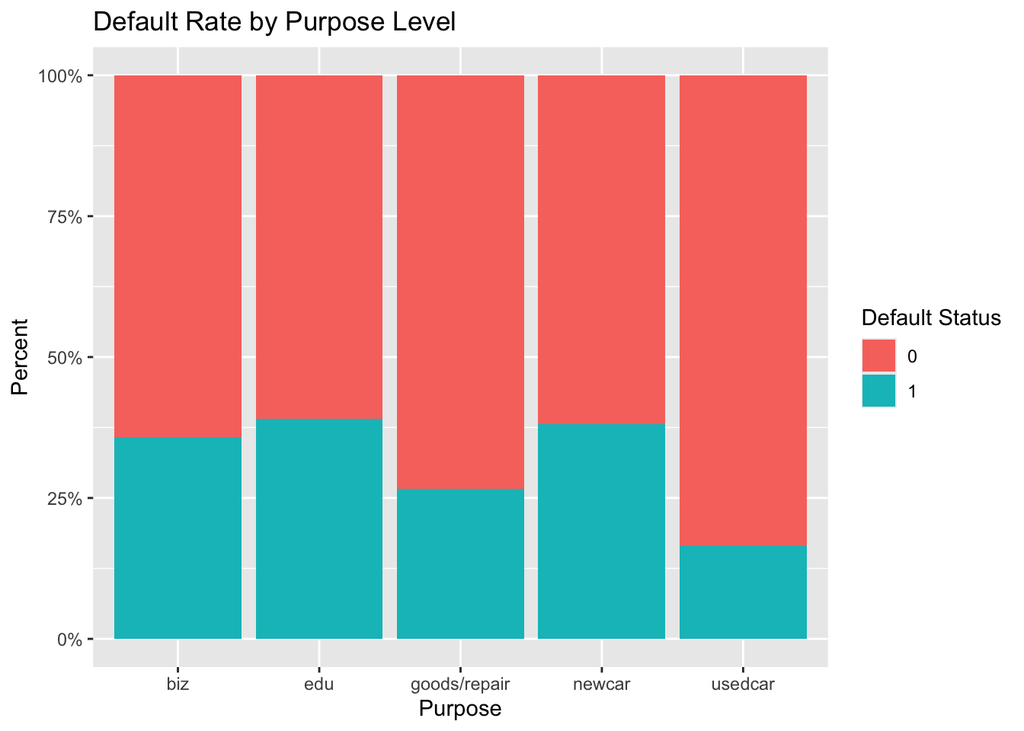

```r
ggplot(creditdf) +
  geom_bar(aes(x = factor(purpose), fill = factor(Default)), position = "fill") +
  scale_y_continuous(labels = scales::percent) +
  labs(title = "Default Rate by Purpose Level",
       x = "Purpose", y = "Percent", fill = "Default Status")
```

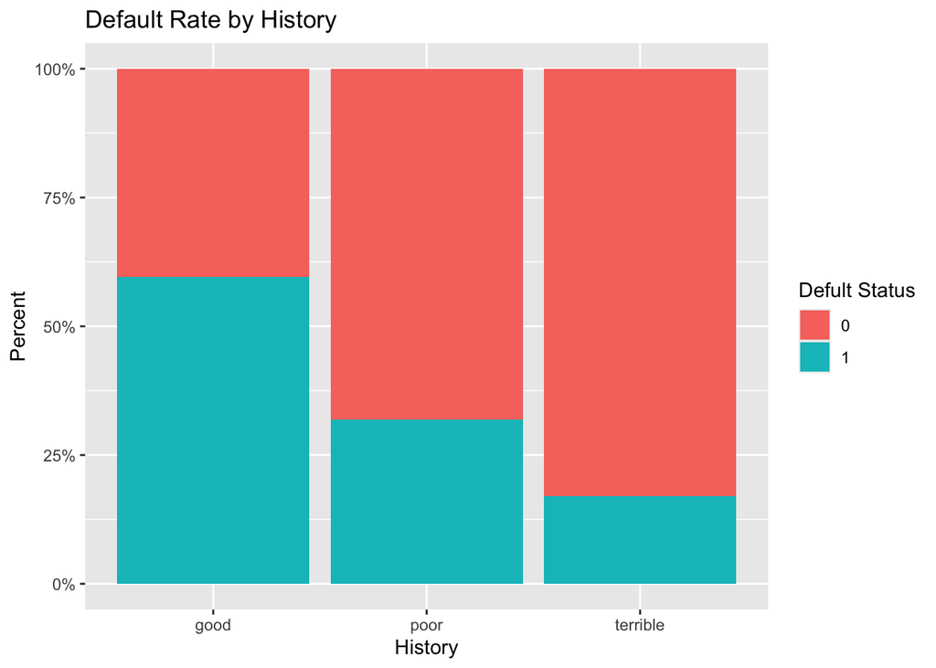

```r
ggplot(creditdf) +
  geom_bar(aes(x = factor(history), fill = factor(Default)), position = "fill") +
  scale_y_continuous(labels = scales::percent) +
  labs(title = "Default Rate by History",
       x = "History", y = "Percent", fill = "Defult Status")
```

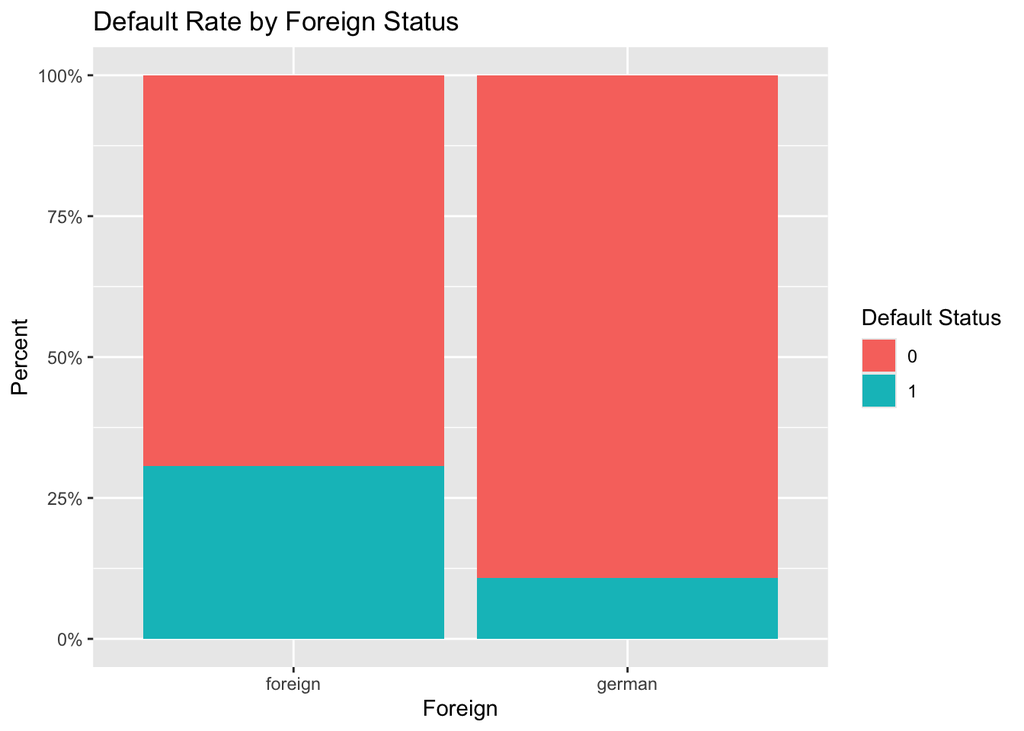

```r
ggplot(creditdf) +
  geom_bar(aes(x = factor(foreign), fill = factor(Default)), position = "fill") +
  scale_y_continuous(labels = scales::percent) +
  labs(title = "Default Rate by Foreign Status",
       x = "Foreign", y = "Percent", fill = "Default Status")
```

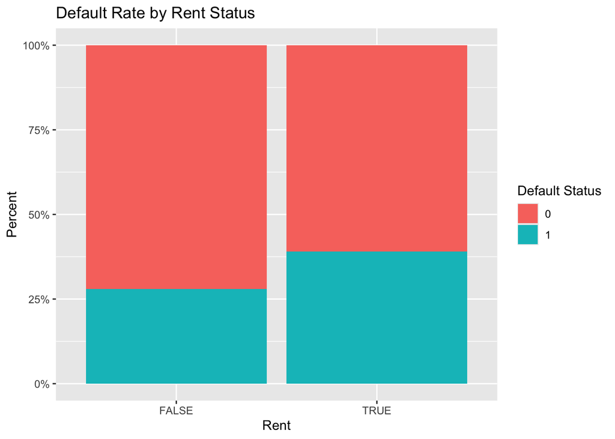

```r
ggplot(creditdf) +
  geom_bar(aes(x = factor(rent), fill = factor(Default)), position = "fill") +
  scale_y_continuous(labels = scales::percent) +
  labs(title = "Default Rate by Rent Status",
       x = "Rent", y = "Percent", fill = "Default Status")
```

```r
#example conduct a chi-square test of association between two categorical variables
#install.packages("gmodels")

CrossTable(creditdf$installment, creditdf$Default,
           prop.chisq = FALSE, prop.c = TRUE, prop.r = TRUE,
           prop.t = TRUE, chisq = TRUE)
```

```
   Cell Contents
|-------------------------|
|                       N |
|           N / Row Total |
|           N / Col Total |
|         N / Table Total |
|-------------------------|


Total Observations in Table:  1000


                     | creditdf$Default
creditdf$installment |         0 |         1 | Row Total |
---------------------|-----------|-----------|-----------|
                   1 |       102 |        34 |       136 |
                     |     0.750 |     0.250 |     0.136 |
                     |     0.146 |     0.113 |           |
                     |     0.102 |     0.034 |           |
---------------------|-----------|-----------|-----------|
                   2 |       169 |        62 |       231 |
                     |     0.732 |     0.268 |     0.231 |
                     |     0.241 |     0.207 |           |
                     |     0.169 |     0.062 |           |
---------------------|-----------|-----------|-----------|
                   3 |       112 |        45 |       157 |
                     |     0.713 |     0.287 |     0.157 |
                     |     0.160 |     0.150 |           |
                     |     0.112 |     0.045 |           |
---------------------|-----------|-----------|-----------|
                   4 |       317 |       159 |       476 |
                     |     0.666 |     0.334 |     0.476 |
                     |     0.453 |     0.530 |           |
                     |     0.317 |     0.159 |           |
---------------------|-----------|-----------|-----------|
        Column Total |       700 |       300 |      1000 |
                     |     0.700 |     0.300 |           |
---------------------|-----------|-----------|-----------|


Statistics for All Table Factors


Pearson's Chi-squared test
------------------------------------------------------------
Chi^2 =  5.476792     d.f. =  3     p =  0.1400333
```

```r
CrossTable(creditdf$amount, creditdf$Default,
           prop.chisq = FALSE, prop.c = TRUE, prop.r = TRUE,
           prop.t = TRUE, chisq = TRUE)
```

```
   Cell Contents
|-------------------------|
|                       N |
|           N / Row Total |
|           N / Col Total |
|         N / Table Total |
|-------------------------|


Total Observations in Table:  1000


                | creditdf$Default
creditdf$amount |         0 |         1 | Row Total |
----------------|-----------|-----------|-----------|
            250 |         1 |         0 |         1 |
                |     1.000 |     0.000 |     0.001 |
                |     0.001 |     0.000 |           |
                |     0.001 |     0.000 |           |
----------------|-----------|-----------|-----------|
            276 |         1 |         0 |         1 |
                |     1.000 |     0.000 |     0.001 |
                |     0.001 |     0.000 |           |
                |     0.001 |     0.000 |           |
----------------|-----------|-----------|-----------|
            338 |         1 |         0 |         1 |
                |     1.000 |     0.000 |     0.001 |
                |     0.001 |     0.000 |           |
                |     0.001 |     0.000 |           |
----------------|-----------|-----------|-----------|
            339 |         1 |         0 |         1 |
                |     1.000 |     0.000 |     0.001 |
                |     0.001 |     0.000 |           |
                |     0.001 |     0.000 |           |
----------------|-----------|-----------|-----------|
            343 |         1 |         0 |         1 |
                |     1.000 |     0.000 |     0.001 |
                |     0.001 |     0.000 |           |
                |     0.001 |     0.000 |           |
----------------|-----------|-----------|-----------|
```

[output cut: 4576 more lines]

```
                |     0.000 |     1.000 |     0.001 |
                |     0.000 |     0.003 |           |
                |     0.000 |     0.001 |           |
----------------|-----------|-----------|-----------|
   Column Total |       700 |       300 |      1000 |
                |     0.700 |     0.300 |           |
----------------|-----------|-----------|-----------|


Statistics for All Table Factors


Pearson's Chi-squared test
------------------------------------------------------------
Chi^2 =  931.746     d.f. =  920     p =  0.3865968
```

```r
CrossTable(creditdf$duration, creditdf$Default,
           prop.chisq = FALSE, prop.c = TRUE, prop.r = TRUE,
           prop.t = TRUE, chisq = TRUE)
```

```
   Cell Contents
|-------------------------|
|                       N |
|           N / Row Total |
|           N / Col Total |
|         N / Table Total |
|-------------------------|


Total Observations in Table:  1000


                  | creditdf$Default
creditdf$duration |         0 |         1 | Row Total |
------------------|-----------|-----------|-----------|
                4 |         6 |         0 |         6 |
                  |     1.000 |     0.000 |     0.006 |
                  |     0.009 |     0.000 |           |
                  |     0.006 |     0.000 |           |
------------------|-----------|-----------|-----------|
                5 |         1 |         0 |         1 |
                  |     1.000 |     0.000 |     0.001 |
                  |     0.001 |     0.000 |           |
                  |     0.001 |     0.000 |           |
------------------|-----------|-----------|-----------|
                6 |        66 |         9 |        75 |
                  |     0.880 |     0.120 |     0.075 |
                  |     0.094 |     0.030 |           |
                  |     0.066 |     0.009 |           |
------------------|-----------|-----------|-----------|
                7 |         5 |         0 |         5 |
                  |     1.000 |     0.000 |     0.005 |
                  |     0.007 |     0.000 |           |
                  |     0.005 |     0.000 |           |
------------------|-----------|-----------|-----------|
                8 |         6 |         1 |         7 |
                  |     0.857 |     0.143 |     0.007 |
                  |     0.009 |     0.003 |           |
                  |     0.006 |     0.001 |           |
------------------|-----------|-----------|-----------|
```

[output cut: 136 more lines]

```
                  |     0.000 |     1.000 |     0.001 |
                  |     0.000 |     0.003 |           |
                  |     0.000 |     0.001 |           |
------------------|-----------|-----------|-----------|
     Column Total |       700 |       300 |      1000 |
                  |     0.700 |     0.300 |           |
------------------|-----------|-----------|-----------|


Statistics for All Table Factors


Pearson's Chi-squared test
------------------------------------------------------------
Chi^2 =  78.88694     d.f. =  32     p =  7.784572e-06
```

### Task 3: Fit a logistic model

Fit a logistic model to determine whether `amount` is a good predictor of `Default`.

1. Then interpret the coefficient of `amount` as
   1. the log-odds of default increasses by 0.0001 for each $1 increase in amount
   2. the odds of default increases by .01% for each $1 increase in amount
2. Generate a plot of the logistic model predicted probabilities over
   1. the given amount values,
   2. a new range of amount values (0 to 50,000)
3. Calculate the probability of default for amount=$1000 , amount=$1001 , amount=$10000, and amount=$10001

```r
#1
options(scipen = 999)

#fit a logistic model
creditmodel <- glm(Default ~ amount, family="binomial", data=creditdf)

summary(creditmodel)
```

```
Call:
glm(formula = Default ~ amount, family = "binomial", data = creditdf)

Coefficients:
               Estimate  Std. Error z value             Pr(>|z|)
(Intercept) -1.22937493  0.10833192 -11.348 < 0.0000000000000002 ***
amount       0.00011189  0.00002355   4.751           0.00000202 ***
---
Signif. codes:  0 '***' 0.001 '**' 0.01 '*' 0.05 '.' 0.1 ' ' 1

(Dispersion parameter for binomial family taken to be 1)

    Null deviance: 1221.7  on 999  degrees of freedom
Residual deviance: 1199.1  on 998  degrees of freedom
AIC: 1203.1

Number of Fisher Scoring iterations: 4
```

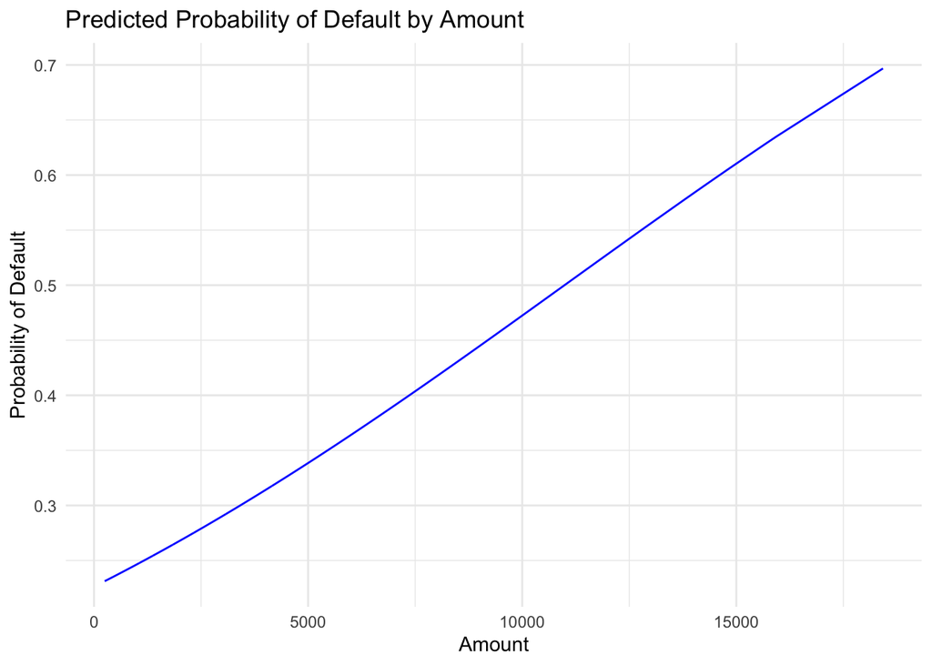

```r
#2
#a. just use the values of amounts in the original dataset
creditdf$predprob <- predict(creditmodel, type="response")
ggplot(creditdf, aes(x = amount, y = predprob)) +
  geom_line(color = "blue") +
  labs(
    title = "Predicted Probability of Default by Amount",
    x = "Amount",
    y = "Probability of Default"
  ) +
  theme_minimal()
```

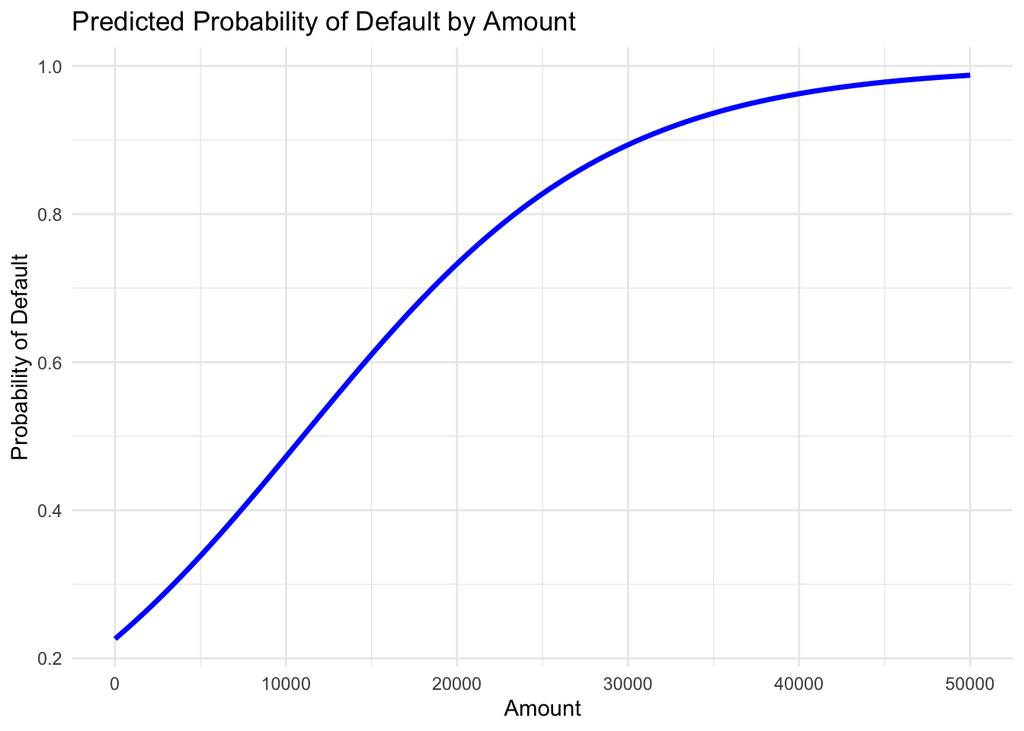

```r
#b. set a range for 'amount'
min_amt <- 0
max_amt <- 50000

# Create a sequence of amounts across the observed range
amount_seq <- data.frame(amount = seq(min_amt, max_amt, length.out = 300))

# Predict probabilities for each amount
amount_seq$prob_default <- predict(creditmodel, newdata = amount_seq, type = "response")

# Plot the sigmoid curve
ggplot(amount_seq, aes(x = amount, y = prob_default)) +
  geom_line(color = "blue", size = 1.2) +
  labs(
    title = "Predicted Probability of Default by Amount",
    x = "Amount",
    y = "Probability of Default"
  ) +
  theme_minimal()
```

```r
#3.
#set specific values for amount
new_amounts <- data.frame(amount = c(1000, 1001, 10000, 10001))

# Predict probabilities of default
new_amounts$predicted_prob <- predict(creditmodel, newdata = new_amounts, type = "response")

# View results
print(new_amounts)
```

```
  amount predicted_prob
1   1000      0.2464789
2   1001      0.2464997
3  10000      0.4724197
4  10001      0.4724476
```

### Task 4: Model validity

Determine whether the logistic model assumptions are satisfied:

1. Binary response–already checked in EDA

2. Fully-represented data matrix (N/A)

3. Linearity

4. Multicollinearity (N/A)

5. Independence–assume this 6. No large outliers/influentials

Recall that normality is not an assumption, but the QQ plot can still be used to help see outliers.

What do you learn about the linearity assumption?

```r
summary(creditmodel)
```

```
Call:
glm(formula = Default ~ amount, family = "binomial", data = creditdf)

Coefficients:
               Estimate  Std. Error z value             Pr(>|z|)
(Intercept) -1.22937493  0.10833192 -11.348 < 0.0000000000000002 ***
amount       0.00011189  0.00002355   4.751           0.00000202 ***
---
Signif. codes:  0 '***' 0.001 '**' 0.01 '*' 0.05 '.' 0.1 ' ' 1

(Dispersion parameter for binomial family taken to be 1)

    Null deviance: 1221.7  on 999  degrees of freedom
Residual deviance: 1199.1  on 998  degrees of freedom
AIC: 1203.1

Number of Fisher Scoring iterations: 4
```

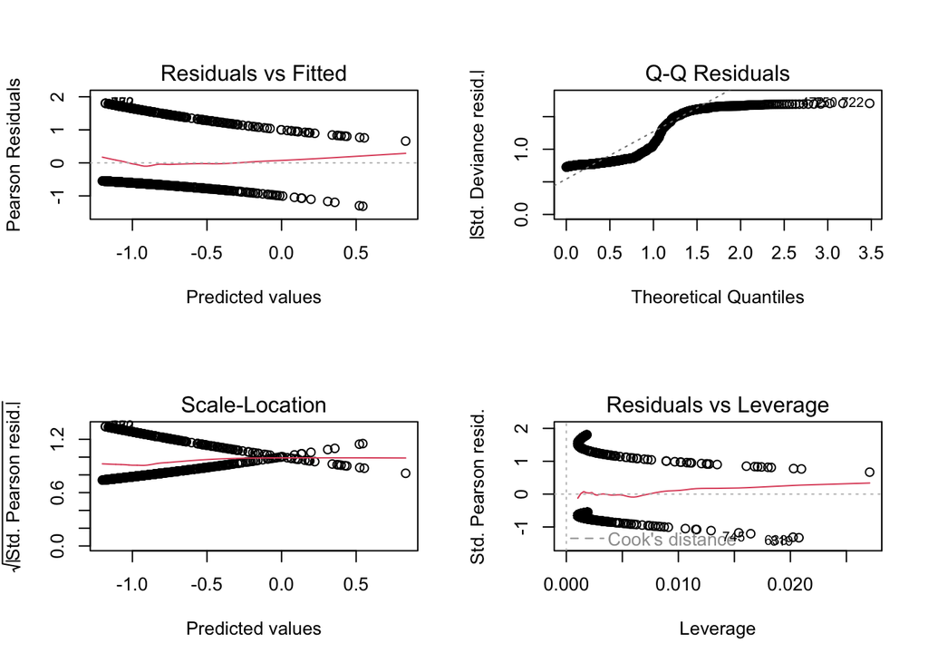

```r
par(mfrow=c(2,2))
plot(creditmodel)
```

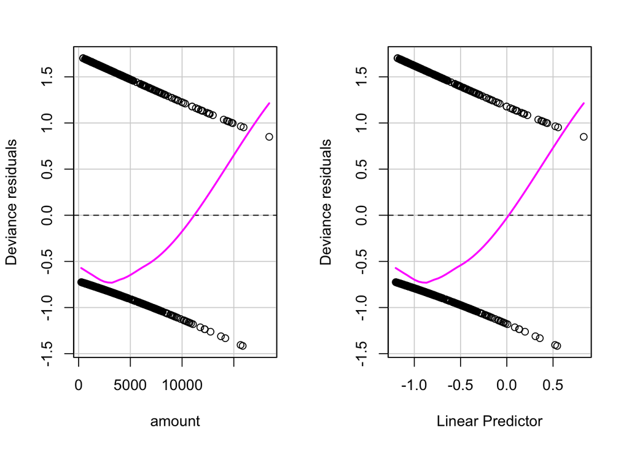

```
       Test stat Pr(>|Test stat|)
amount    3.5304          0.06025 .
---
Signif. codes:  0 '***' 0.001 '**' 0.01 '*' 0.05 '.' 0.1 ' ' 1
```

```r
residualPlots(creditmodel, type="deviance", smooth=TRUE)
```

### Task 5: Model Accuracy & ROC Curve

1. Generate a confusion matrix and accuracy % for the classification rule p=0.5
2. Generate a confusion matrix and accuracy % for the classification rule p=0.75
3. Generate an ROC curve for the model and calculate AUC.

Interpret the ROC curve.

The ROC curve helps to highlight the relationship between sensitivity and specificity for various thresholds. For instance, and AUC closer to 1 suggests excellent distinction between sensitivity and specificity. In contrast, an AUC closer to 0.5 suggets that the model is no better than random guessing. Our AUC score of 0.5549 suggests that our model is only slightly better at distinguishing between the two than just random guessing.

```r
# Classify using threshold 0.5
creditdf$pred_class_05 <- ifelse(creditdf$predprob>=0.5, 1, 0)

# Confusion matrix
table(Predicted = creditdf$pred_class_05, Actual = creditdf$Default)
```

```
         Actual
Predicted   0   1
        0 691 280
        1   9  20
```

```r
# Accuracy
accuracy_05 <- mean(creditdf$pred_class_05 == creditdf$Default)
cat("Accuracy at p = 0.5:", round(accuracy_05 * 100, 2), "%\n")
```

```
Accuracy at p = 0.5: 71.1 %
```

```r
# Classify using threshold 0.75

creditdf$pred_class_075 <- ifelse(creditdf$predprob>=0.75, 1, 0)

# Confusion matrix
table(Predicted = creditdf$pred_class_075, Actual = creditdf$Default)
```

```
         Actual
Predicted   0   1
        0 700 300
```

```r
# Accuracy
accuracy_075 <- mean(creditdf$pred_class_075 == creditdf$Default)
cat("Accuracy at p = 0.75:", round(accuracy_075 * 100, 2), "%\n")
```

```
Accuracy at p = 0.75: 70 %
```

```r
#ROC curve
dev.off()
```

```r
# Compute ROC and plot
roc_obj <- roc(creditdf$Default, creditdf$predprob)
plot(roc_obj, legacy.axes=T, col = "blue", main = "ROC Curve for Default Model")

# Calculate AUC
auc_value <- auc(roc_obj)
cat("AUC:", round(auc_value, 4), "\n")
```

[output not shown]

```
AUC: 0.5549
```

### Task 6: Model Goodness-of-fit

Use the following measures:

1. ROC / AUC

2. McFadden’s Pseudo R^2

3. Significance test for predictor

4. LRT for null model vs. model

5. Compare Deviance and AIC of model vs. null model

Summarize what you learn.

I learned that the model does not have a very good fit to the data. For instance, the McFadden’s Pseudo R^2 value is very low at 0.01855, indicating that the model only explains a small portion of the variance in the outcome variable. However, the p-value shows that the model is statistically significant, so it plays a small part in painting the whole picture. Our AUC value from earlier of 0.5549 suggests that the model is only slightly better than random guessing between those who default and those who do not. Overall, we have found that the null model vs. model is not a great predictor, so we need to look into other models. The deviance and AIC values are also not very good, which further supports that this model is not a good fit for this data.

```r
mcfadden_r2 <- 1 - (creditmodel$deviance / creditmodel$null.deviance)
print(mcfadden_r2)
```

```
[1] 0.01855134
```

```r
null_model <- glm(Default ~ 1, family="binomial", data=creditdf)
summary(null_model)
```

```
Call:
glm(formula = Default ~ 1, family = "binomial", data = creditdf)

Coefficients:
            Estimate Std. Error z value            Pr(>|z|)
(Intercept) -0.84730    0.06901  -12.28 <0.0000000000000002 ***
---
Signif. codes:  0 '***' 0.001 '**' 0.01 '*' 0.05 '.' 0.1 ' ' 1

(Dispersion parameter for binomial family taken to be 1)

    Null deviance: 1221.7  on 999  degrees of freedom
Residual deviance: 1221.7  on 999  degrees of freedom
AIC: 1223.7

Number of Fisher Scoring iterations: 4
```

```r
library(lmtest)
lrtest(null_model,creditmodel)
```

| #Df | LogLik | Df | Chisq | Pr(>Chisq) |
| --- | --- | --- | --- | --- |
| 1 | -610.8643 | NA | NA | NA |
| 2 | -599.5320 | 1 | 22.6647 | 0.0000019 |